# User Guide

## Introduction

#### PhenEndo is a data mining and visualization tool for studying endotypes targeted for questionnaire or other biomedical records. With its features and design it helps the user to develop its own medical data analysis application, as it provides a step-by-step guidance from getting the first feature simple statistics to advanced cluster analysis.

#### To make you confident with Phenendo functionalities, we will walk you through the whole process by showing you a small example with our custom dataset. It can be downloaded here. The dataset contains 33 categorical and numerical attributes. To specify the features datatype, we also provide a second file, containing a name list of all attributes and their data types.

## Upload Data

#### This tool supports numerical as well as categorical data, such as survey data. For this purpose, we recommend the user to upload two data files.

#### The first one contains the attributes (or features) which are going to be analyzed for every biomedical record.

#### The second one annotates the data type of all features in the dataset.

#### Phenendo accepts .csv, .txt, .xlsx data files. To get an idea of the data format, please check with our custom data.

## Data Visualization

#### Three types of data visualization are provided to help the user get first insights of the data.

### Heatmap

#### Here, we present a heatmap of the data entries, which are scaled between 1/(number of unique feature values) and 1 The y-axis represents the features and the x-axis the data items. For example, in our sample data attributes 5, 8 and 24 have lower values (the cells of the corresponding entries are mainly in the blue scale).

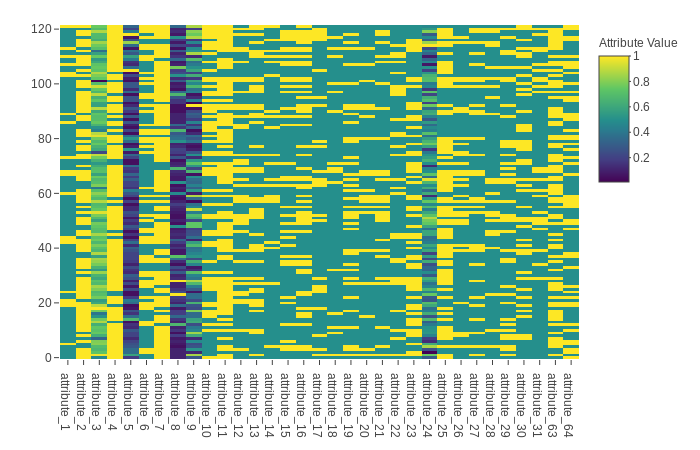

### Attribute Barplots

#### A barplot or a histogram of every attribute is provided, to describe its distribution structure. For example, in many of these plots one can see the imbalance in the binary variables, for instance attribute_1, attribute_4, attribute_7 and so on. These highly biased sets add to the noise in the data. On the other hand, if they co-occur they can be the deciding factor for the clustering algorithms. See next section on FAMD.

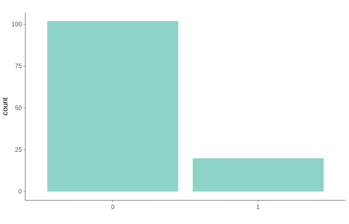

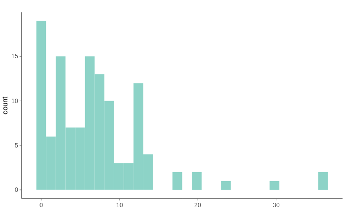

### FAMD Plots

#### Factor Analysis for Mixed Data (FAMD) is a version of PCA, which considers the categorical features in the dataset. The generated plots study the relationship between the different features, projected on the two components, which have the greatest eigenvalues. In our case the first and second components explain at most approx. 19% of the variance.

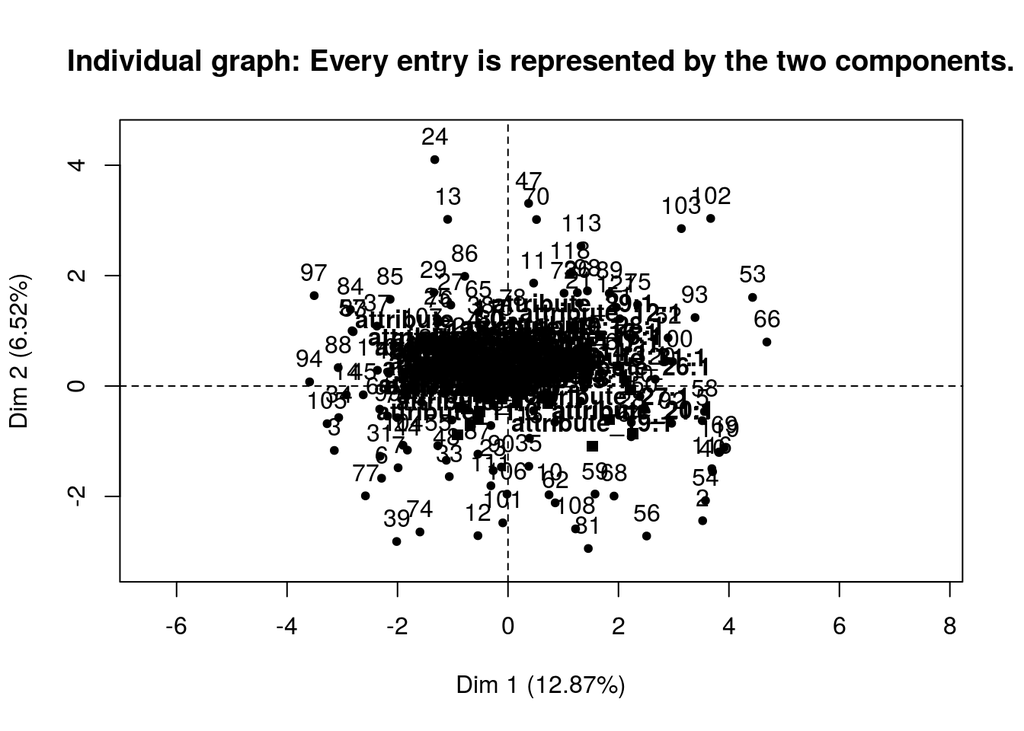

#### The quantitative plot indicates that some of the continuous features are dependent, e.g. it seems that attributes 8 and 5 are (perfectly) negative correlated.

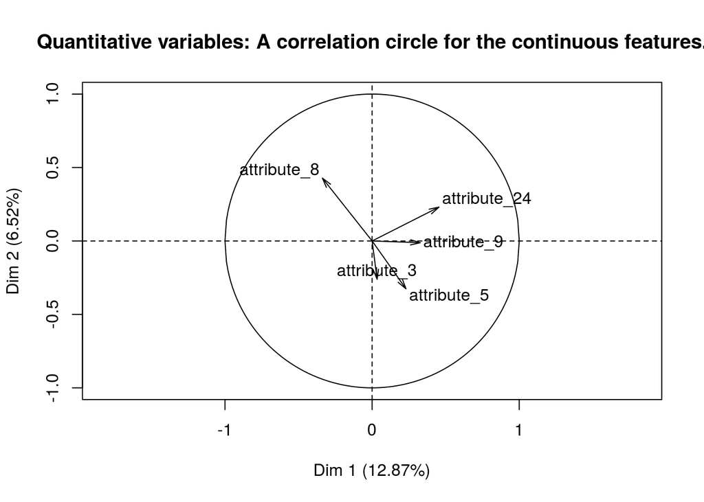

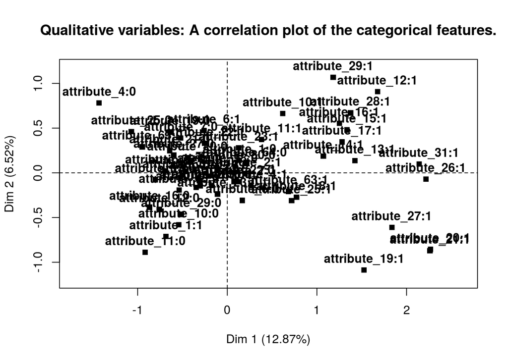

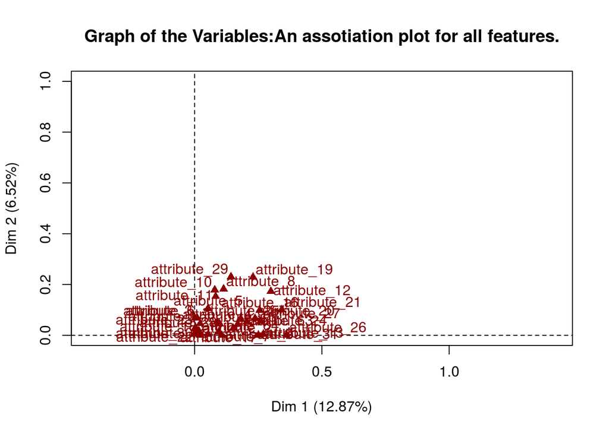

## Consensus Clustering

#### To determine the number of clusters, Consensus Clustering is used. The data first is subsampled and afterwards is clustered several times with number of clusters ranging from 2 to a number given by the user. Each clustering is evaluated by generating a consensus matrix, whose entries store the proportion of clustering runs in which two items are clustered together. Here, we won’t consider the consensus matrix itself, but its summary statistics. Note that for this experiment, hierarchical clustering with Ward.D2 clustering criterion is chosen. Moreover, the clustering distance is the Gower distance, which considers the presence of categorical features in the dataset. The output plots of this procedure help the user optimally determine the number of clusters from the dataset.

### Clustering Selection

#### The cummulative distrbution of the consensus matrix entries (CDF) is a useful statistic for evaluating the calculated clusters. The shape of each CDF curve gives information about the presence of a cluster. In the ideal case the CDF corresponding to every clustering after reaching the optimal one should resemble the CDF curve of the optimal clustering.

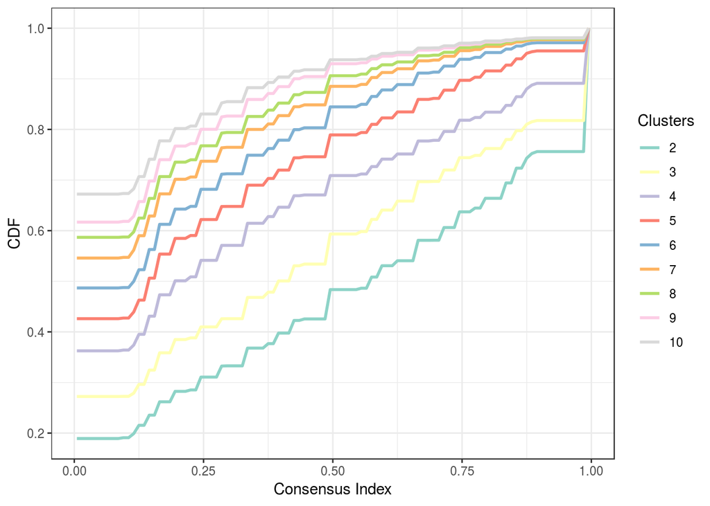

#### Alternatively, the clustering assessment can be done by inspecting the delta plot, which shows the area under the CDF curve for each clustering. It allows the user to observe the relative increase in consensus (y-axis) and determine the number of clusters K at which there is no appreciable increase. After the true K is reached there should be no significant change in the area under the CDF. Both the CDF and Delta plots suggest that the optimal number of clusters is 6.

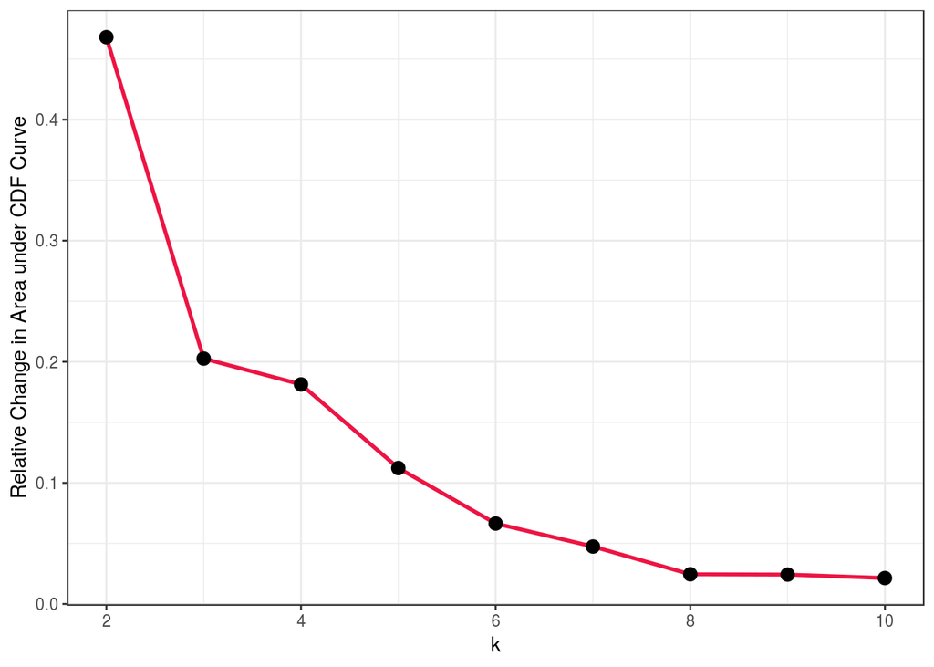

### Clustering Visualization

#### Additionally, the user can visualize the chosen clusters directly on the dataset heatmap. As in the Raw Data Visualization section the coloring of the cells represents the feature values.

#### Look at our example with two clusters.

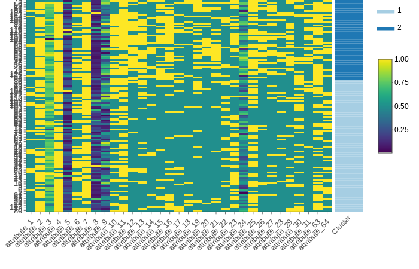

## Clustering Signature

#### The last functionality in PhenEndo studies the attributes importance for the cluster seperation. Therefore, we fit a mutlinomial GLM with covariates the data and response the assigned clusters. The carried-out cluster analysis suggests that the optimal number of clusters is 6. Therefore, we set up the experience for 6 labels, corresponding to the clusters ids.

#### The obtained model parameters are visualized in a heatmap as this below. Note that the coefficients for cluster 4 are missing since it contains less than 10% of all observations.

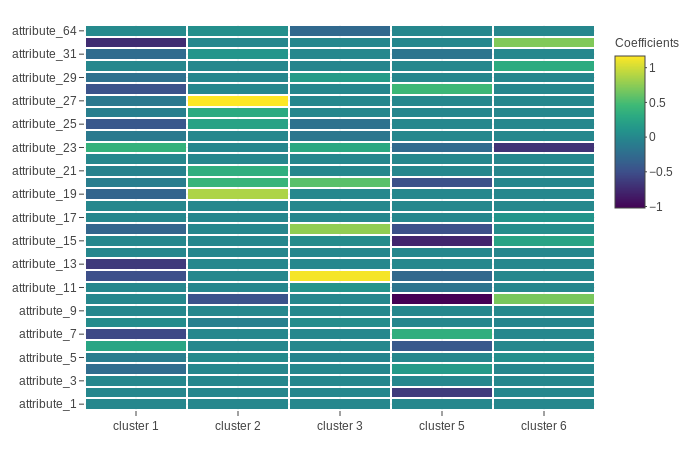

#### For each attribute in the dataset we provide a conditional bar plot (for categorical) or conditional box plot (for numerical data), i.e. for each cluster the attribute's distibution is shown.

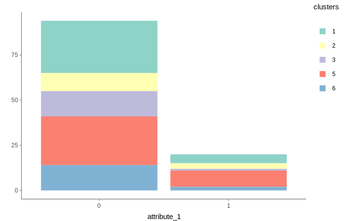

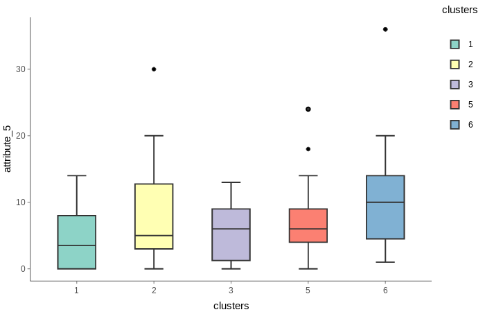